# CPSC 540 Homework 1: Marketing Campaign Analysis

Matthew Tonks

2025-10-13

# Analysis

## Overview

This report analyzes synthetic marketing data from Company X, a wellness brand, to answer two key business questions about customer purchasing behavior and campaign effectiveness. The dataset includes 5,000 customers with information about demographics, purchasing history, and response to a new “Be Well” campaign with three variants.

```r
# Load the marketing campaign data
data <- read_csv("marketingcampaign.csv", show_col_types = FALSE)

# Convert categorical variables to factors
data <- data %>%
    mutate(gender = factor(gender), campaign_variant = factor(campaign_variant,
        levels = c("A", "B", "C")), ad_source = factor(ad_source), email_signup = factor(email_signup))

# Display basic information
cat("Dataset dimensions:", nrow(data), "rows ×", ncol(data), "columns\n")
```

```
## Dataset dimensions: 5000 rows × 7 columns
```

```r
cat("Number of missing values:", sum(is.na(data)), "\n\n")
```

```
## Number of missing values: 0
```

## Question 1: What kinds of people make MORE purchases?

### Analytical Approach

To understand which customer characteristics are associated with higher purchase frequency, I employed **Negative Binomial Regression**. This choice was driven by the nature of the outcome variable:

- **Past purchases** is a count variable (discrete, non-negative integers)
- The data exhibits **overdispersion** (variance >> mean), violating the Poisson assumption
- Negative Binomial regression explicitly models this overdispersion through a dispersion parameter

```r
# Check distribution characteristics
mean_purchases <- mean(data$past_purchases)
var_purchases <- var(data$past_purchases)
ratio <- var_purchases/mean_purchases

cat("Past Purchases Distribution:\n")
```

```
## Past Purchases Distribution:
```

```r
cat("  Mean:", round(mean_purchases, 2), "\n")
```

```
##   Mean: 41.05
```

```r
cat("  Variance:", round(var_purchases, 2), "\n")
```

```
##   Variance: 364.48
```

```r
cat("  Variance/Mean ratio:", round(ratio, 2), "\n")
```

```
##   Variance/Mean ratio: 8.88
```

```r
cat("\nInterpretation: Ratio >> 1 indicates OVERDISPERSION\n")
```

```
##
## Interpretation: Ratio >> 1 indicates OVERDISPERSION
```

```r
cat("Recommendation: Use Negative Binomial (not Poisson)\n")
```

```
## Recommendation: Use Negative Binomial (not Poisson)
```

**Models Fitted:**

The Negative Binomial approach is appropriate because it:

- Handles count data with overdispersion
- Provides interpretable incident rate ratios (IRR)
- Is commonly used in marketing analytics for purchase frequency
- Offers robust inference for business decision-making

### Why This Method?

Count data requires specialized statistical methods. Using standard linear regression would be inappropriate because:

- Predictions could be negative (impossible for counts)
- Distributional assumptions (normality) would be violated
- Standard errors would be incorrect

The Negative Binomial model specifically addresses the overdispersion observed in the data, where some customers make many more purchases than the average, creating variance that exceeds the mean.

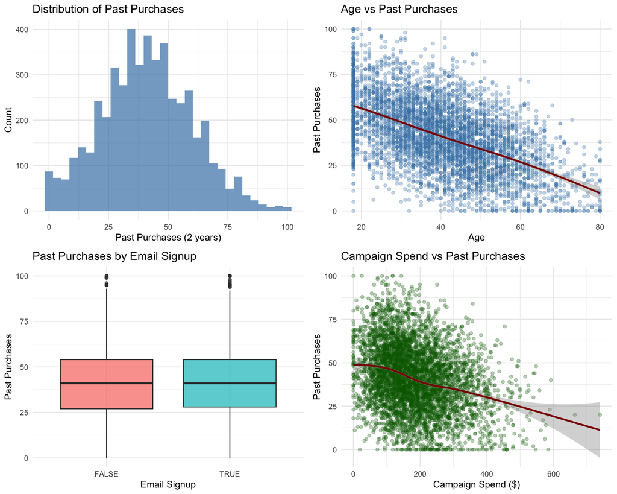

```r
# Exploratory visualizations for Question 1
p1 <- ggplot(data, aes(x = past_purchases)) + geom_histogram(bins = 30,
    fill = "steelblue", alpha = 0.7) + labs(title = "Distribution of Past Purchases",
    x = "Past Purchases (2 years)", y = "Count") + theme_minimal()

p2 <- ggplot(data, aes(x = age, y = past_purchases)) + geom_point(alpha = 0.3,
    color = "steelblue") + geom_smooth(method = "loess", color = "darkred",
    se = TRUE) + labs(title = "Age vs Past Purchases", x = "Age", y = "Past Purchases") +
    theme_minimal()

p3 <- ggplot(data, aes(x = email_signup, y = past_purchases, fill = email_signup)) +
    geom_boxplot(alpha = 0.7) + labs(title = "Past Purchases by Email Signup",
    x = "Email Signup", y = "Past Purchases") + theme_minimal() + theme(legend.position = "none")

p4 <- ggplot(data, aes(x = campaign_spend, y = past_purchases)) + geom_point(alpha = 0.3,
    color = "darkgreen") + geom_smooth(method = "loess", color = "darkred",
    se = TRUE) + labs(title = "Campaign Spend vs Past Purchases", x = "Campaign Spend ($)",
    y = "Past Purchases") + theme_minimal()

grid.arrange(p1, p2, p3, p4, ncol = 2)
```